# Neural Spike Analysis Project

##### Our success rates accross the sessions varied there was a slight upward trend of higher percentages towards the later sessions. This may be due to the on-average higher traial count as well.

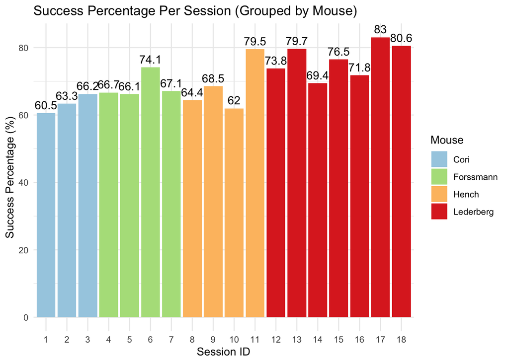

##### The mouse, Lederberg had the highest overall percentage of successes with Cori having the lowest. This further suggests that number of trials and sessions may impact success rate.

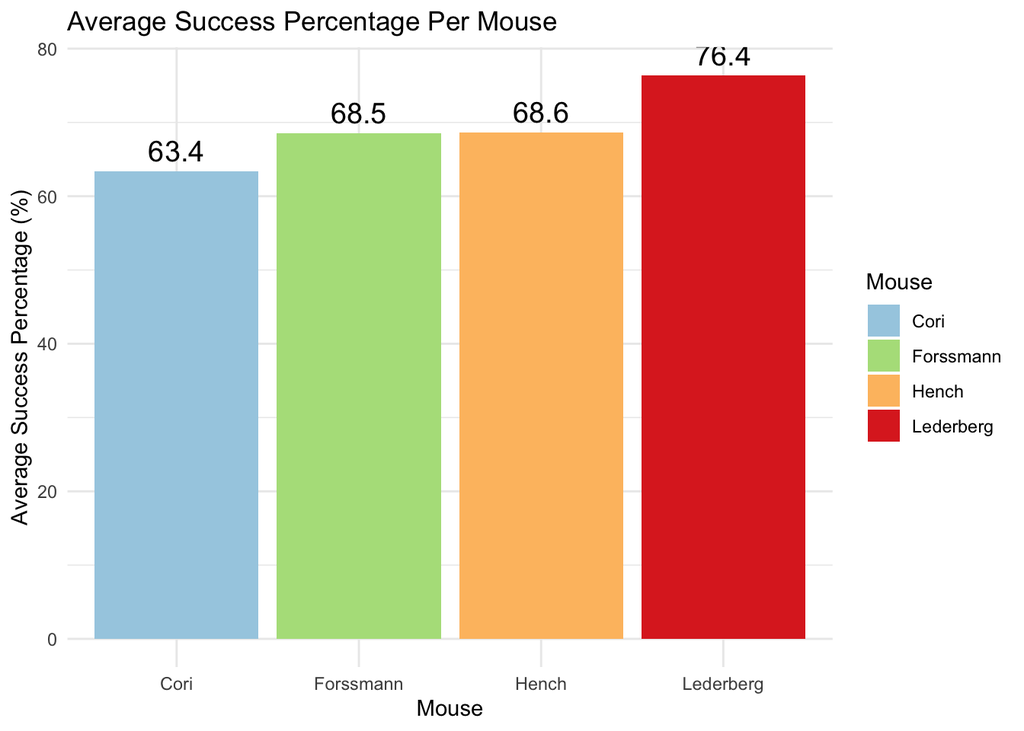

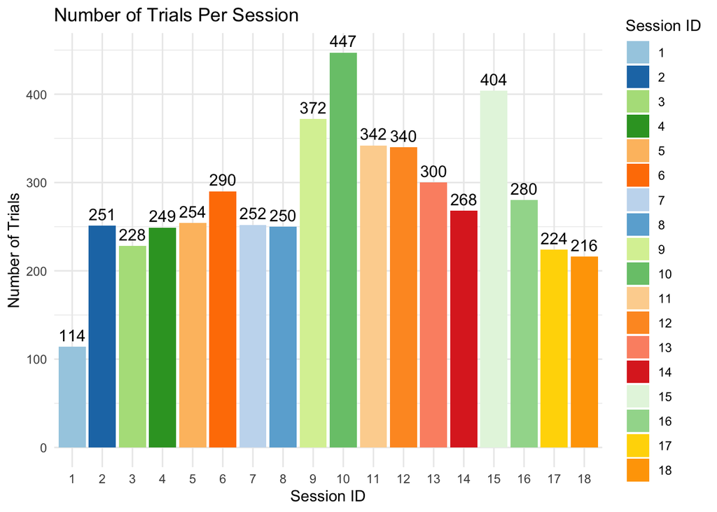

##### Above is a graph showing the number of trials per session.

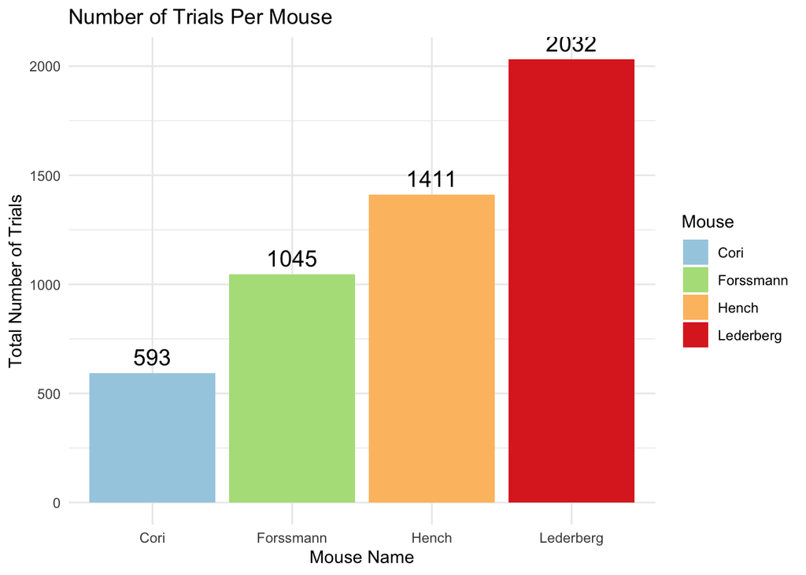

##### The number of trials varied greatly between the four mice. This may influence the success rate and other outcomes of study.

### Session 3 Data Integration

##### Next we modified the data in preparation to prep it for model training. We used normalization. This step was simple and represents a base to our analysis.

### Section 4 Predictive Modeling

##### Next we built our predictive model. We merged the dataset to format. Using PCA and XGBoost Model Training.

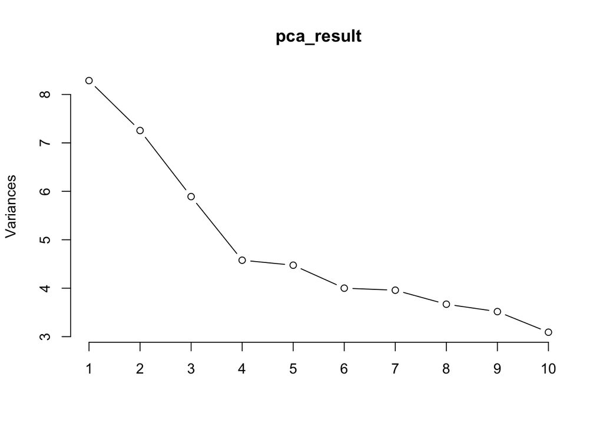

```
## [1] "Test Accuracy: 70.6 %"
```

```
##          Actual
## Predicted    0    1
##         0   63   77
##         1  371 1013
```

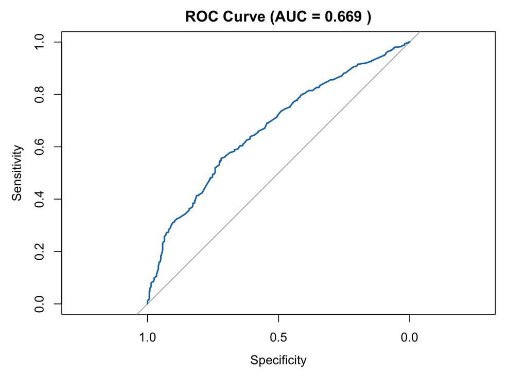

### Session 5 Test Data

##### This section was unsuccessful due to time restraints.

```r
# # Convert test data into a dataframe for predictions
# test_trials_df <- bind_rows(lapply(seq_along(test_sessions), function(i) {
#   data.frame(
#     session_ID = i + 18,  # Assign new session IDs (assuming training data had 18 sessions)
#     contrast_left = test_sessions[[i]]$contrast_left,
#     contrast_right = test_sessions[[i]]$contrast_right,
#     avg_neuron_spike_rate = mean(unlist(test_sessions[[i]]$spks), na.rm = TRUE),
#     num_neurons = length(unique(test_sessions[[i]]$brain_area))
#   )
# }))
#
# # Check test data structure
# print(head(test_trials_df))
#
#
# # Select same predictors used in training
# predictors <- c("contrast_left", "contrast_right", "avg_neuron_spike_rate")
#
# # Convert test data to matrix
# test_matrix <- as.matrix(test_trials_df[, predictors])
#
# # Create XGBoost DMatrix
# dtest_new <- xgb.DMatrix(data = test_matrix)
```

### Discussion

##### This report is far from thurough. However we gained valuable insights and have a direction moving forward.

### acknowledgements

##### https://chatgpt.com/share/67d8b3f7-7218-8001-ae9f-dfbc90b6a2b3

#### Study Paper

##### https://discovery.ucl.ac.uk/id/eprint/10087006/1/Steinmetz%20et%20al%202019%20-%20Revised%20Manuscript.pdf